# Flight Delay Analysis

```python
import pandas as pd
import numpy as np
import matplotlib.pyplot as plt
import seaborn as sns
```

```python
pip install plotting
```

### Data Sourcing

```python
# reading and displaying the data
flight = pd.read_csv("C:/Users/HP/Desktop/Airline_Delay_Cause.csv")
flight
```

|  | year | month | carrier | carrier_name | airport | airport_name | arr_flights | arr_del15 | carrier_ct | weather_ct | ... | security_ct | late_aircraft_ct | arr_cancelled | arr_diverted | arr_delay | carrier_delay | weather_delay | nas_delay | security_delay | late_aircraft_delay |
| --- | --- | --- | --- | --- | --- | --- | --- | --- | --- | --- | --- | --- | --- | --- | --- | --- | --- | --- | --- | --- | --- |
| 0 | 2022 | 5 | 9E | Endeavor Air Inc. | ABE | Allentown/Bethlehem/Easton, PA: Lehigh Valley ... | 136.0 | 7.0 | 5.95 | 0.00 | ... | 0.0 | 1.00 | 0.0 | 0.0 | 255.0 | 222.0 | 0.0 | 4.0 | 0.0 | 29.0 |
| 1 | 2022 | 5 | 9E | Endeavor Air Inc. | ABY | Albany, GA: Southwest Georgia Regional | 91.0 | 16.0 | 7.38 | 0.00 | ... | 0.0 | 6.09 | 0.0 | 0.0 | 884.0 | 351.0 | 0.0 | 81.0 | 0.0 | 452.0 |
| 2 | 2022 | 5 | 9E | Endeavor Air Inc. | ACK | Nantucket, MA: Nantucket Memorial | 19.0 | 2.0 | 0.13 | 0.00 | ... | 0.0 | 0.88 | 1.0 | 0.0 | 138.0 | 4.0 | 0.0 | 106.0 | 0.0 | 28.0 |
| 3 | 2022 | 5 | 9E | Endeavor Air Inc. | AEX | Alexandria, LA: Alexandria International | 88.0 | 14.0 | 7.26 | 0.76 | ... | 0.0 | 1.64 | 0.0 | 0.0 | 947.0 | 585.0 | 35.0 | 125.0 | 0.0 | 202.0 |
| 4 | 2022 | 5 | 9E | Endeavor Air Inc. | AGS | Augusta, GA: Augusta Regional at Bush Field | 181.0 | 19.0 | 13.84 | 0.00 | ... | 0.0 | 2.09 | 0.0 | 0.0 | 808.0 | 662.0 | 0.0 | 87.0 | 0.0 | 59.0 |
| ... | ... | ... | ... | ... | ... | ... | ... | ... | ... | ... | ... | ... | ... | ... | ... | ... | ... | ... | ... | ... | ... |
| 318012 | 2003 | 6 | DL | Delta Air Lines Inc. | SEA | Seattle, WA: Seattle/Tacoma International | 480.0 | 84.0 | 25.69 | 3.09 | ... | 0.0 | 21.26 | 0.0 | 0.0 | 3744.0 | 978.0 | 164.0 | 1023.0 | 0.0 | 1579.0 |
| 318013 | 2003 | 6 | DL | Delta Air Lines Inc. | SFO | San Francisco, CA: San Francisco International | 505.0 | 111.0 | 21.78 | 2.24 | ... | 0.0 | 13.17 | 3.0 | 0.0 | 4284.0 | 1376.0 | 138.0 | 2132.0 | 0.0 | 638.0 |
| 318014 | 2003 | 6 | DL | Delta Air Lines Inc. | SJC | San Jose, CA: Norman Y. Mineta San Jose Intern... | 146.0 | 36.0 | 6.99 | 0.00 | ... | 0.0 | 2.15 | 0.0 | 0.0 | 896.0 | 205.0 | 0.0 | 607.0 | 0.0 | 84.0 |
| 318015 | 2003 | 6 | DL | Delta Air Lines Inc. | SJU | San Juan, PR: Luis Munoz Marin International | 95.0 | 13.0 | 3.66 | 0.00 | ... | 0.0 | 1.42 | 0.0 | 0.0 | 367.0 | 120.0 | 0.0 | 210.0 | 0.0 | 37.0 |
| 318016 | 2003 | 6 | DL | Delta Air Lines Inc. | SLC | Salt Lake City, UT: Salt Lake City International | 3466.0 | 454.0 | 121.15 | 7.61 | ... | 1.0 | 102.33 | 9.0 | 0.0 | 16853.0 | 5384.0 | 306.0 | 5686.0 | 28.0 | 5449.0 |

318017 rows × 21 columns

```python
#showing the head of the data
flight.head()
```

|  | year | month | carrier | carrier_name | airport | airport_name | arr_flights | arr_del15 | carrier_ct | weather_ct | ... | security_ct | late_aircraft_ct | arr_cancelled | arr_diverted | arr_delay | carrier_delay | weather_delay | nas_delay | security_delay | late_aircraft_delay |
| --- | --- | --- | --- | --- | --- | --- | --- | --- | --- | --- | --- | --- | --- | --- | --- | --- | --- | --- | --- | --- | --- |
| 0 | 2022 | 5 | 9E | Endeavor Air Inc. | ABE | Allentown/Bethlehem/Easton, PA: Lehigh Valley ... | 136.0 | 7.0 | 5.95 | 0.00 | ... | 0.0 | 1.00 | 0.0 | 0.0 | 255.0 | 222.0 | 0.0 | 4.0 | 0.0 | 29.0 |
| 1 | 2022 | 5 | 9E | Endeavor Air Inc. | ABY | Albany, GA: Southwest Georgia Regional | 91.0 | 16.0 | 7.38 | 0.00 | ... | 0.0 | 6.09 | 0.0 | 0.0 | 884.0 | 351.0 | 0.0 | 81.0 | 0.0 | 452.0 |
| 2 | 2022 | 5 | 9E | Endeavor Air Inc. | ACK | Nantucket, MA: Nantucket Memorial | 19.0 | 2.0 | 0.13 | 0.00 | ... | 0.0 | 0.88 | 1.0 | 0.0 | 138.0 | 4.0 | 0.0 | 106.0 | 0.0 | 28.0 |
| 3 | 2022 | 5 | 9E | Endeavor Air Inc. | AEX | Alexandria, LA: Alexandria International | 88.0 | 14.0 | 7.26 | 0.76 | ... | 0.0 | 1.64 | 0.0 | 0.0 | 947.0 | 585.0 | 35.0 | 125.0 | 0.0 | 202.0 |
| 4 | 2022 | 5 | 9E | Endeavor Air Inc. | AGS | Augusta, GA: Augusta Regional at Bush Field | 181.0 | 19.0 | 13.84 | 0.00 | ... | 0.0 | 2.09 | 0.0 | 0.0 | 808.0 | 662.0 | 0.0 | 87.0 | 0.0 | 59.0 |

5 rows × 21 columns

```python
#showing tail of data
flight.tail()
```

|  | year | month | carrier | carrier_name | airport | airport_name | arr_flights | arr_del15 | carrier_ct | weather_ct | ... | security_ct | late_aircraft_ct | arr_cancelled | arr_diverted | arr_delay | carrier_delay | weather_delay | nas_delay | security_delay | late_aircraft_delay |
| --- | --- | --- | --- | --- | --- | --- | --- | --- | --- | --- | --- | --- | --- | --- | --- | --- | --- | --- | --- | --- | --- |
| 318012 | 2003 | 6 | DL | Delta Air Lines Inc. | SEA | Seattle, WA: Seattle/Tacoma International | 480.0 | 84.0 | 25.69 | 3.09 | ... | 0.0 | 21.26 | 0.0 | 0.0 | 3744.0 | 978.0 | 164.0 | 1023.0 | 0.0 | 1579.0 |
| 318013 | 2003 | 6 | DL | Delta Air Lines Inc. | SFO | San Francisco, CA: San Francisco International | 505.0 | 111.0 | 21.78 | 2.24 | ... | 0.0 | 13.17 | 3.0 | 0.0 | 4284.0 | 1376.0 | 138.0 | 2132.0 | 0.0 | 638.0 |
| 318014 | 2003 | 6 | DL | Delta Air Lines Inc. | SJC | San Jose, CA: Norman Y. Mineta San Jose Intern... | 146.0 | 36.0 | 6.99 | 0.00 | ... | 0.0 | 2.15 | 0.0 | 0.0 | 896.0 | 205.0 | 0.0 | 607.0 | 0.0 | 84.0 |
| 318015 | 2003 | 6 | DL | Delta Air Lines Inc. | SJU | San Juan, PR: Luis Munoz Marin International | 95.0 | 13.0 | 3.66 | 0.00 | ... | 0.0 | 1.42 | 0.0 | 0.0 | 367.0 | 120.0 | 0.0 | 210.0 | 0.0 | 37.0 |
| 318016 | 2003 | 6 | DL | Delta Air Lines Inc. | SLC | Salt Lake City, UT: Salt Lake City International | 3466.0 | 454.0 | 121.15 | 7.61 | ... | 1.0 | 102.33 | 9.0 | 0.0 | 16853.0 | 5384.0 | 306.0 | 5686.0 | 28.0 | 5449.0 |

5 rows × 21 columns

```python
# Displaying datatypes of each column
flight.info()
```

```
<class 'pandas.core.frame.DataFrame'>
RangeIndex: 318017 entries, 0 to 318016
Data columns (total 21 columns):
 #   Column               Non-Null Count   Dtype
---  ------               --------------   -----
 0   year                 318017 non-null  int64
 1   month                318017 non-null  int64
 2   carrier              318017 non-null  object
 3   carrier_name         318017 non-null  object
 4   airport              318017 non-null  object
 5   airport_name         318017 non-null  object
 6   arr_flights          317529 non-null  float64
 7   arr_del15            317289 non-null  float64
 8   carrier_ct           317529 non-null  float64
 9   weather_ct           317529 non-null  float64
 10  nas_ct               317529 non-null  float64
 11  security_ct          317529 non-null  float64
 12  late_aircraft_ct     317529 non-null  float64
 13  arr_cancelled        317529 non-null  float64
 14  arr_diverted         317529 non-null  float64
 15  arr_delay            317529 non-null  float64
 16  carrier_delay        317529 non-null  float64
 17  weather_delay        317529 non-null  float64
 18  nas_delay            317529 non-null  float64
 19  security_delay       317529 non-null  float64
 20  late_aircraft_delay  317529 non-null  float64
dtypes: float64(15), int64(2), object(4)
memory usage: 51.0+ MB
```

```python
#getting number of rows and columns
flight.shape
```

```
(318017, 21)
```

```python
#Unique count of each column
flight.nunique (axis=0, dropna=True)
```

```
year                      20
month                     12
carrier                   29
carrier_name              33
airport                  420
airport_name             420
arr_flights             7292
arr_del15               2315
carrier_ct             18352
weather_ct              5575
nas_ct                 21031
security_ct             1145
late_aircraft_ct       22206
arr_cancelled            672
arr_diverted             138
arr_delay              28025
carrier_delay          14358
weather_delay           5388
nas_delay              14086
security_delay           662
late_aircraft_delay    17665
dtype: int64
```

```python
# unique values of airport column
flight['airport'].unique()
```

```
array(['ABE', 'ABY', 'ACK', 'AEX', 'AGS', 'ALB', 'ATL', 'ATW', 'AUS',
       'AVL', 'AZO', 'BGM', 'BGR', 'BHM', 'BMI', 'BNA', 'BOS', 'BQK',
       'BTR', 'BTV', 'BUF', 'BWI', 'CAE', 'CHA', 'CHO', 'CHS', 'CID',
       'CLE', 'CLT', 'CMH', 'CRW', 'CSG', 'CVG', 'CWA', 'DAY', 'DCA',
       'DHN', 'DLH', 'DSM', 'DTW', 'EVV', 'EWR', 'EYW', 'FAY', 'FSD',
       'FWA', 'GNV', 'GPT', 'GRR', 'GSO', 'GSP', 'GTR', 'HPN', 'ILM',
       'IND', 'ITH', 'JFK', 'LAN', 'LEX', 'LFT', 'LGA', 'MBS', 'MCI',
       'MEM', 'MGM', 'MKE', 'MLI', 'MLU', 'MOB', 'MOT', 'MSN', 'MSP',
       'MYR', 'OAJ', 'OMA', 'ORD', 'ORF', 'ORH', 'PIT', 'PVD', 'RDU',
       'RIC', 'ROA', 'ROC', 'RST', 'SAV', 'SBN', 'SDF', 'SGF', 'SHV',
       'STL', 'SYR', 'TLH', 'TRI', 'TVC', 'TYS', 'VLD', 'XNA', 'ABQ',
       'AMA', 'ANC', 'AVP', 'BDL', 'BOI', 'BUR', 'BZN', 'COS', 'DEN',
       'DFW', 'EGE', 'ELP', 'EUG', 'FAT', 'FCA', 'FLL', 'GEG', 'HNL',
       'IAD', 'IAH', 'ICT', 'JAX', 'KOA', 'LAS', 'LAX', 'LBB', 'LIH',
       'LIT', 'MCO', 'MDT', 'MFE', 'MIA', 'MSO', 'MSY', 'OGG', 'OKC',
       'ONT', 'PBI', 'PDX', 'PHL', 'PHX', 'PNS', 'PSP', 'PWM', 'RNO',
       'RSW', 'SAN', 'SAT', 'SBA', 'SEA', 'SFO', 'SJC', 'SJU', 'SLC',
       'SMF', 'SNA', 'SRQ', 'STT', 'STX', 'TPA', 'TUL', 'TUS', 'VPS',
       'ADK', 'ADQ', 'AKN', 'BET', 'BRW', 'CDV', 'DAL', 'DLG', 'FAI',
       'GST', 'JNU', 'KTN', 'OAK', 'OME', 'OTZ', 'PAE', 'PSG', 'SCC',
       'SIT', 'WRG', 'YAK', 'BQN', 'HYA', 'MVY', 'PSE', 'BIL', 'DAB',
       'ECP', 'FAR', 'GRB', 'HOU', 'HSV', 'IDA', 'JAN', 'MDW', 'MLB',
       'BIS', 'BKG', 'DRO', 'GJT', 'HRL', 'ILG', 'ISP', 'SWF', 'TTN',
       'AZA', 'BLI', 'BLV', 'CAK', 'CKB', 'ELM', 'FNT', 'GFK', 'GRI',
       'GTF', 'HGR', 'HTS', 'IAG', 'LCK', 'LRD', 'MFR', 'MRY', 'OWB',
       'PBG', 'PGD', 'PIA', 'PIE', 'PSC', 'PSM', 'PVU', 'RAP', 'RDM',
       'RFD', 'SCE', 'SCK', 'SFB', 'SMX', 'SPI', 'STC', 'TOL', 'USA',
       'ITO', 'LGB', 'PPG', 'ABI', 'ACT', 'ALO', 'BFL', 'BPT', 'BRO',
       'CLL', 'CMI', 'COU', 'CRP', 'DBQ', 'DRT', 'FSM', 'GCK', 'GGG',
       'GRK', 'HHH', 'LAW', 'LCH', 'LSE', 'MAF', 'MHK', 'MQT', 'SBP',
       'SJT', 'SPS', 'STS', 'SWO', 'TXK', 'TYR', 'ACY', 'LBE', 'MHT',
       'EWN', 'LYH', 'PHF', 'ABR', 'ACV', 'ALS', 'APN', 'ASE', 'BFF',
       'BJI', 'BRD', 'BTM', 'CDC', 'CGI', 'CIU', 'CMX', 'CNY', 'COD',
       'CPR', 'CYS', 'DDC', 'DEC', 'DIK', 'DVL', 'EAR', 'EAU', 'EKO',
       'ESC', 'FLG', 'FOD', 'GCC', 'GUC', 'HDN', 'HIB', 'HLN', 'HOB',
       'HYS', 'IMT', 'INL', 'JLN', 'JMS', 'JST', 'LAR', 'LBF', 'LBL',
       'LNK', 'LWB', 'LWS', 'MCW', 'MEI', 'MKG', 'MTJ', 'OGS', 'OTH',
       'PAH', 'PIB', 'PIH', 'PLN', 'PRC', 'PUB', 'RDD', 'RHI', 'RIW',
       'RKS', 'ROW', 'SAF', 'SGU', 'SHD', 'SHR', 'SLN', 'SUN', 'SUX',
       'TBN', 'TWF', 'VCT', 'VEL', 'WYS', 'XWA', 'YUM', 'ALW', 'EAT',
       'PUW', 'YKM', 'GUM', 'SPN', 'JAC', 'OGD', 'ERI', 'BIH', 'ATY',
       'PIR', 'HVN', 'CDB', 'IPT', 'BFM', 'MMH', 'UIN', 'PGV', 'ISN',
       'ART', 'YNG', 'IFP', 'FNL', 'UST', 'TKI', 'ENV', 'EFD', 'CLD',
       'CEC', 'MCN', 'CIC', 'FOE', 'LMT', 'MOD', 'IYK', 'IPL', 'TUP',
       'UTM', 'TEX', 'FLO', 'MWH', 'OXR', 'PFN', 'PMD', 'SLE', 'SOP',
       'APF', 'MTH', 'MKC', 'GLH', 'ISO', 'RCA', 'HKY', 'VIS', 'FMN',
       'LNY', 'MKK', 'ILE', 'SKA', 'CBM', 'DUT'], dtype=object)
```

```python
#getting the length of unique airport names
len(flight["airport"].unique())
```

```
420
```

## Data Cleaning

```python
# Identifying number of null values in each column
flight.isnull().sum()
```

```
year                     0
month                    0
carrier                  0
carrier_name             0
airport                  0
airport_name             0
arr_flights            488
arr_del15              728
carrier_ct             488
weather_ct             488
nas_ct                 488
security_ct            488
late_aircraft_ct       488
arr_cancelled          488
arr_diverted           488
arr_delay              488
carrier_delay          488
weather_delay          488
nas_delay              488
security_delay         488
late_aircraft_delay    488
dtype: int64
```

Converting the count of null values into percentile to get better insight

```python
#obtaining the count of null values in persentile to have a better insight
flight.isnull().sum() * 100 / len(flight)
```

```
year                   0.000000
month                  0.000000
carrier                0.000000
carrier_name           0.000000
airport                0.000000
airport_name           0.000000
arr_flights            0.153451
arr_del15              0.228919
carrier_ct             0.153451
weather_ct             0.153451
nas_ct                 0.153451
security_ct            0.153451
late_aircraft_ct       0.153451
arr_cancelled          0.153451
arr_diverted           0.153451
arr_delay              0.153451
carrier_delay          0.153451
weather_delay          0.153451
nas_delay              0.153451
security_delay         0.153451
late_aircraft_delay    0.153451
dtype: float64
```

### Dealing with null values

since the percentage of missing value is very less it can be dropped

```python
flight1 = flight.dropna()
```

```python
flight.shape
```

```
(318017, 21)
```

```python
flight1.shape
```

```
(317289, 21)
```

As we can see now the missing values are dropped

### Checking Duplicates

```python
flight1.duplicated().sum()
```

```
0
```

as we can see there is no duplicate values

## Dropping the unwanted columns

colums such as carrier_ct, weather_ct, nas_ct,security_ct, late_aircraft_ct are of no use in analysis thus we can drop it

```python
flight1.drop(['carrier_ct','weather_ct','nas_ct','security_ct','late_aircraft_ct'],axis=1,inplace=True)
```

```python
flight1.head()
```

|  | year | month | carrier | carrier_name | airport | airport_name | arr_flights | arr_del15 | arr_cancelled | arr_diverted | arr_delay | carrier_delay | weather_delay | nas_delay | security_delay | late_aircraft_delay |
| --- | --- | --- | --- | --- | --- | --- | --- | --- | --- | --- | --- | --- | --- | --- | --- | --- |
| 0 | 2022 | 5 | 9E | Endeavor Air Inc. | ABE | Allentown/Bethlehem/Easton, PA: Lehigh Valley ... | 136.0 | 7.0 | 0.0 | 0.0 | 255.0 | 222.0 | 0.0 | 4.0 | 0.0 | 29.0 |
| 1 | 2022 | 5 | 9E | Endeavor Air Inc. | ABY | Albany, GA: Southwest Georgia Regional | 91.0 | 16.0 | 0.0 | 0.0 | 884.0 | 351.0 | 0.0 | 81.0 | 0.0 | 452.0 |
| 2 | 2022 | 5 | 9E | Endeavor Air Inc. | ACK | Nantucket, MA: Nantucket Memorial | 19.0 | 2.0 | 1.0 | 0.0 | 138.0 | 4.0 | 0.0 | 106.0 | 0.0 | 28.0 |
| 3 | 2022 | 5 | 9E | Endeavor Air Inc. | AEX | Alexandria, LA: Alexandria International | 88.0 | 14.0 | 0.0 | 0.0 | 947.0 | 585.0 | 35.0 | 125.0 | 0.0 | 202.0 |
| 4 | 2022 | 5 | 9E | Endeavor Air Inc. | AGS | Augusta, GA: Augusta Regional at Bush Field | 181.0 | 19.0 | 0.0 | 0.0 | 808.0 | 662.0 | 0.0 | 87.0 | 0.0 | 59.0 |

hence the above code gets executed and the columns gets dropped

### Describing Data - Statistical analysis

```python
flight1.describe()
```

|  | year | month | arr_flights | arr_del15 | arr_cancelled | arr_diverted | arr_delay | carrier_delay | weather_delay | nas_delay | security_delay | late_aircraft_delay |
| --- | --- | --- | --- | --- | --- | --- | --- | --- | --- | --- | --- | --- |
| count | 317289.000000 | 317289.000000 | 317289.000000 | 317289.000000 | 317289.000000 | 317289.000000 | 317289.000000 | 317289.000000 | 317289.000000 | 317289.000000 | 317289.000000 | 317289.000000 |
| mean | 2012.446356 | 6.498315 | 382.046226 | 72.904403 | 7.206317 | 0.868193 | 4213.131974 | 1287.556685 | 220.734381 | 1100.348105 | 7.220257 | 1597.270268 |
| std | 5.677271 | 3.459955 | 1027.486006 | 198.935595 | 37.227520 | 3.917172 | 12523.106018 | 3516.548396 | 861.825845 | 4638.130463 | 38.868752 | 4926.617274 |
| min | 2003.000000 | 1.000000 | 1.000000 | 0.000000 | 0.000000 | 0.000000 | 0.000000 | 0.000000 | 0.000000 | -19.000000 | 0.000000 | 0.000000 |
| 25% | 2007.000000 | 3.000000 | 59.000000 | 9.000000 | 0.000000 | 0.000000 | 437.000000 | 149.000000 | 0.000000 | 56.000000 | 0.000000 | 79.000000 |
| 50% | 2012.000000 | 6.000000 | 120.000000 | 23.000000 | 1.000000 | 0.000000 | 1203.000000 | 437.000000 | 25.000000 | 203.000000 | 0.000000 | 352.000000 |
| 75% | 2018.000000 | 10.000000 | 274.000000 | 56.000000 | 4.000000 | 1.000000 | 3083.000000 | 1101.000000 | 159.000000 | 602.000000 | 0.000000 | 1111.000000 |
| max | 2022.000000 | 12.000000 | 21977.000000 | 6377.000000 | 4951.000000 | 256.000000 | 433687.000000 | 196944.000000 | 57707.000000 | 238440.000000 | 3760.000000 | 148181.000000 |

### Detecting outliers

```
Distribution of arr_del15
```

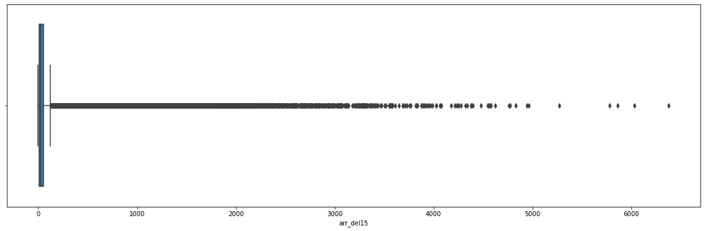

```
Distribution of carrier_delay
```

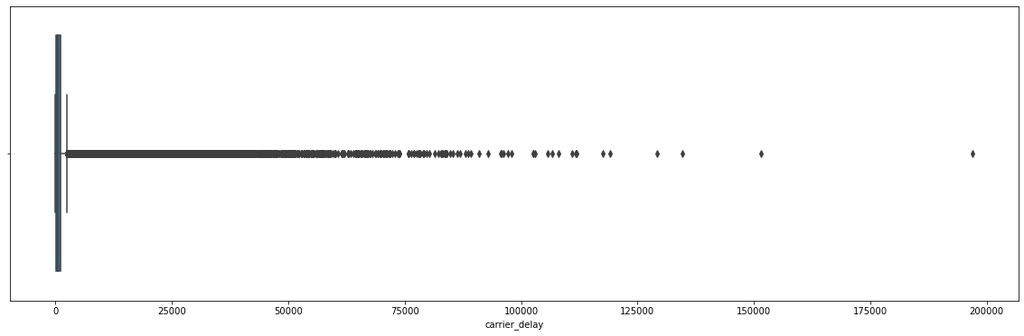

```
Distribution of arr_delay
```

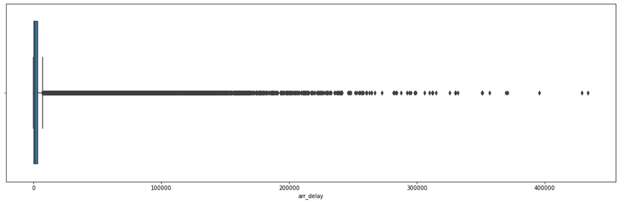

```
Distribution of weather_delay
```

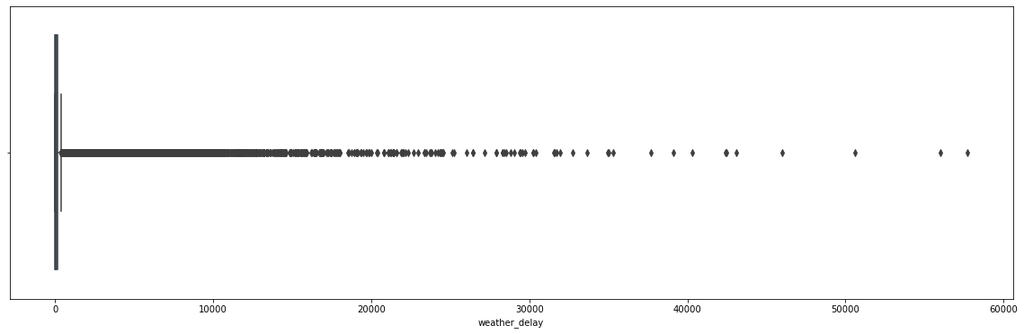

```
Distribution of nas_delay
```

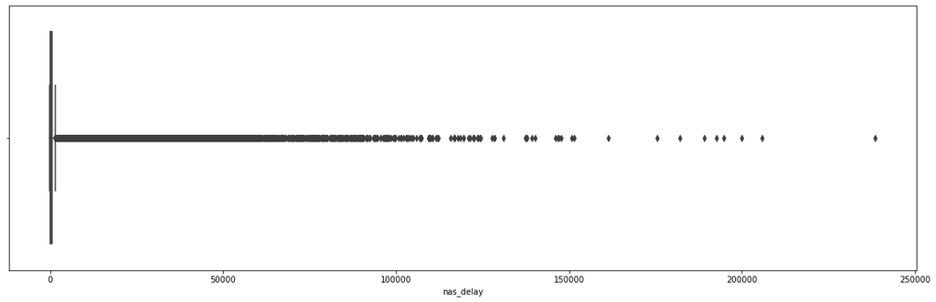

```
Distribution of security_delay
```

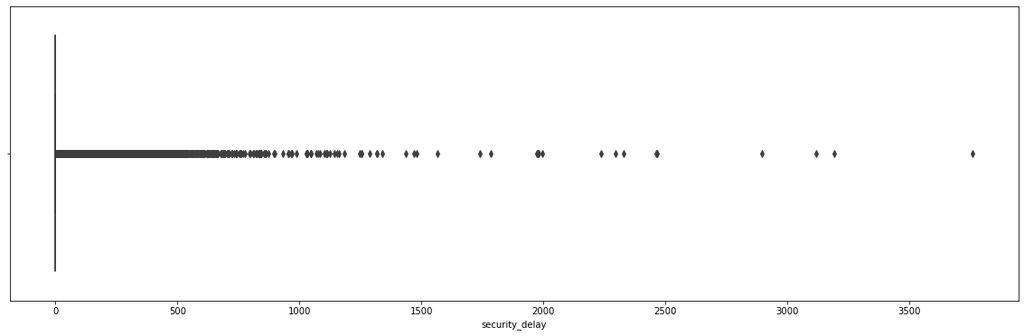

```
Distribution of late_aircraft_delay
```

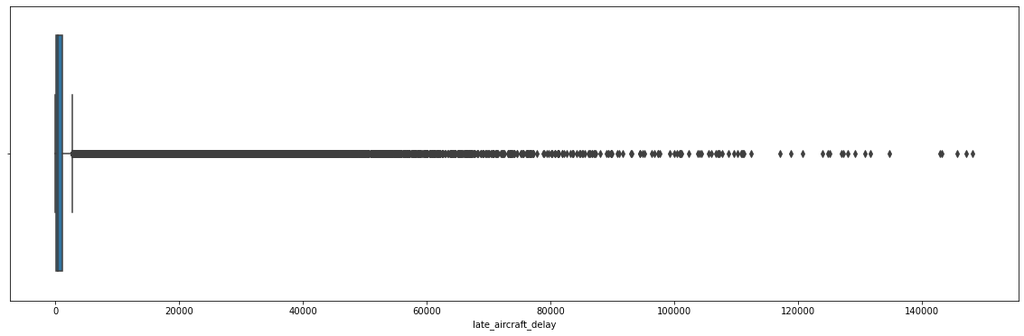

```python
cols = ['arr_del15','carrier_delay','arr_delay','weather_delay','nas_delay','security_delay','late_aircraft_delay']

for i in cols:
    print('Distribution of',i)
    plt.figure(figsize=(20,6))
    sns.boxplot(x = flight1[i])
    plt.show()
```

### As we can see, there are certain outliers present in our data.

```python
# value count of different airports in the dataset
flight1['airport'].value_counts()
```

```
DTW    3022
LAX    2988
LAS    2978
MCI    2964
PIT    2947
       ...
RCA       1
FNL       1
YNG       1
SKA       1
CBM       1
Name: airport, Length: 418, dtype: int64
```

```python
flight1['arr_cancelled'].describe()
```

```
count    317289.000000
mean          7.206317
std          37.227520
min           0.000000
25%           0.000000
50%           1.000000
75%           4.000000
max        4951.000000
Name: arr_cancelled, dtype: float64
```

```python
flight1.loc[flight1['arr_cancelled'] == 4951.00, ['year','month', 'carrier_name', 'airport', 'arr_flights','arr_diverted','arr_delay', 'carrier_delay','weather_delay','nas_delay','security_delay','late_aircraft_delay']]
```

|  | year | month | carrier_name | airport | arr_flights | arr_diverted | arr_delay | carrier_delay | weather_delay | nas_delay | security_delay | late_aircraft_delay |
| --- | --- | --- | --- | --- | --- | --- | --- | --- | --- | --- | --- | --- |
| 42296 | 2020 | 3 | Delta Air Lines Inc. | ATL | 20669.0 | 8.0 | 81479.0 | 49330.0 | 2127.0 | 13887.0 | 0.0 | 16135.0 |

Conclusion : From the stats of 'arr_cancelled', maximun Total flights cancelled is 4951. And it was in the year 2020 in the month of march which was around the initial lockdown announcement due to the COVID-19. Also, since it's late winter, wheather conditions also plays a role.

```python
# Now lets analyse the delay column
flight1['arr_delay'].describe()
```

```
count    317289.000000
mean       4213.131974
std       12523.106018
min           0.000000
25%         437.000000
50%        1203.000000
75%        3083.000000
max      433687.000000
Name: arr_delay, dtype: float64
```

```python
flight1.loc[flight1['arr_delay'] == 433687, ['year','month', 'carrier_name', 'airport', 'arr_flights','arr_diverted','arr_delay', 'carrier_delay','weather_delay','nas_delay','security_delay','late_aircraft_delay']]
```

|  | year | month | carrier_name | airport | arr_flights | arr_diverted | arr_delay | carrier_delay | weather_delay | nas_delay | security_delay | late_aircraft_delay |
| --- | --- | --- | --- | --- | --- | --- | --- | --- | --- | --- | --- | --- |
| 282932 | 2005 | 7 | Delta Air Lines Inc. | ATL | 19043.0 | 187.0 | 433687.0 | 83649.0 | 6867.0 | 238440.0 | 417.0 | 104314.0 |

From the above, we can see that the total maximum arrival delays are again in the ATL airport, during July 2005. The delay is mainly due to NAS delay

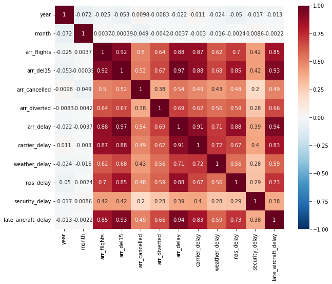

```python
# Getting the dependiencies about each variable
# correlation heatmap
plt.figure(figsize=(10,8))
sns.heatmap(
    flight1.corr(),
    cmap='RdBu_r',
    annot=True,
    vmin=-1, vmax=1);
```

Conclusion:Through the correlation matrix we can see how various variables in the dataset represent multicollinearity.

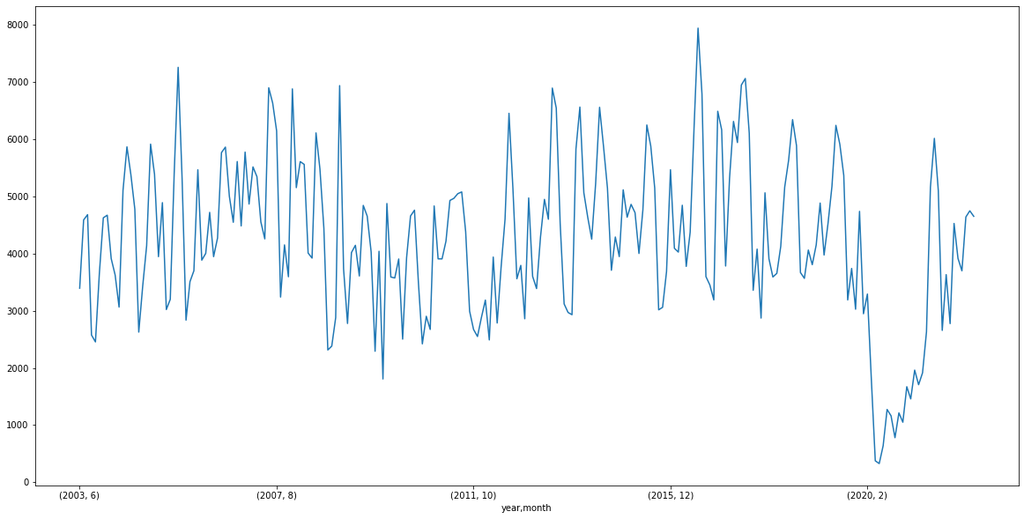

```python
#Analysing average delay of flights on the basis of month and year
flight1.groupby(['year','month']).mean()['arr_delay'].plot(kind='line',figsize=(20,10))
```

Observation: On an average, year 2020 has least arrival delays. Again, the reason being the outbrak of COVID-19, and people didnot travel.

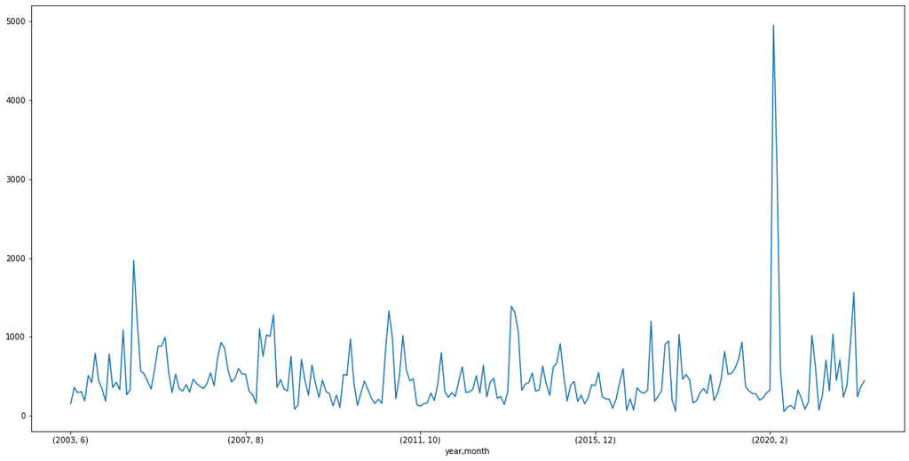

```python
#Analysing the maximum flight canceled on the basis of month and year
flight1.groupby(['year','month']).max()['arr_cancelled'].plot(kind='line',figsize=(20,10))
```

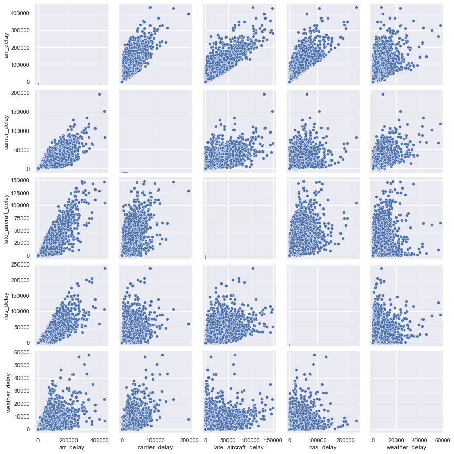

```python
#scatterplot
sns.set()
cols = ['arr_delay', 'carrier_delay', 'late_aircraft_delay', 'nas_delay', 'weather_delay']
sns.pairplot(flight1[cols], size = 2.5)
plt.show()
```

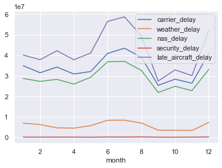

```python
# analysing the most of the delay during the year with the help of line graph
flight1 = flight1.groupby('month')['carrier_delay','weather_delay','nas_delay','security_delay','late_aircraft_delay'].sum().plot()
```

Conclusion: The data contains information of total arrived flights('arr_flights') of different carriers ('carrier_name') in a given month and year at a particular airport ('airport’).

The column (arr_del15) is the total delay caused by five different causes for delay (carrier_ct, weather_ct,nas_ct, security_ct, late_aircraft_ct) Similarly,(arr_delay) is the total delay caused by five different causes for delay (carrier_delay, weather_delay, nas_delay, security_delay ,late_aircraft_delay). Though the columns 'arr_delay15' and 'arr_delay' convey similar information regarding the causes for delay. But, there is no clear infomation regarding the values and how they are connected.

Total maximum arrival delays are in the ATL airport, during July 2005. The delay is mainly due to NAS delay. On an average, year 2020 has least arrival delays. Again, the reason being the outbrak of COVID-19, and people didnot travel. Arrival delays are observed during summers and during christmas/New year time. This is the time where people travel a lot¶